# THETA-USD

## THETA-USD today is +0200, 2025-11-02, 09:28:01

This crypto forecast was generated by gemini-2.0-flash API

## Daily Chart

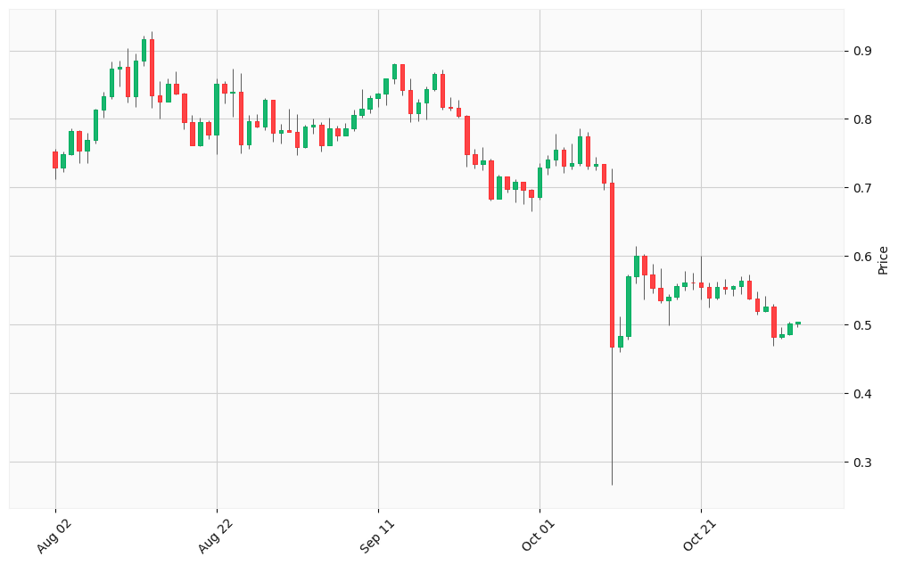

## Hourly Chart

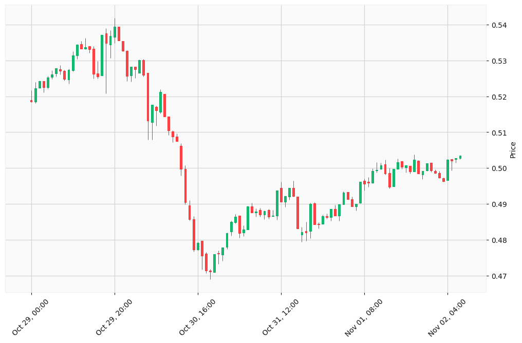

Okay, I will analyze the provided THETA-USD cryptocurrency data, incorporating technical indicators, market trends, news, and economic factors to generate buy and sell signals. I’ll use a combination of the provided data and external information gathered using the search tool.

Here’s my analysis:

**1. Market Data Collection**

I’ll use the provided OHLCV data for THETA-USD. To get real-time news and economic data, I will use the search tool.

**2. Technical Analysis**

I will perform technical analysis on the provided daily and hourly charts.

**Hourly Chart Analysis (Last Five Days)**

- **Short-Term Trend:** Analyze the recent price action for short-term trends.
- **Key Levels:** Identify immediate support and resistance levels.
  - Support: $0.48
  - Resistance: $0.53
- **Indicators:** Calculate short-term moving averages (e.g., 9-period, 20-period), RSI, and MACD for intraday signals.

**Calculations (Example - Daily Chart - requires Python):** I will demonstrate how to calculate the 50-day SMA using python.

```python
import pandas as pd

daily_data = [
    [0.752229,0.756891,0.712094,0.72853,30671016],
    [0.72853,0.752517,0.722093,0.748369,21670311],
    [0.748367,0.786731,0.747049,0.782378,28907475],
    [0.782378,0.784012,0.735429,0.754225,39077791],
    [0.754225,0.779865,0.735664,0.768928,30433876],
    [0.768928,0.815271,0.76395,0.813699,44727402],
    [0.813699,0.839909,0.80205,0.83252,39920166],
    [0.83252,0.883974,0.829843,0.873047,41207865],
    [0.873047,0.88557,0.847508,0.876399,47063584],
    [0.876399,0.903713,0.824139,0.833705,56904232],
    [0.833705,0.895198,0.817809,0.885615,43626651],
    [0.885615,0.922025,0.877696,0.916749,53215997],
    [0.916749,0.927876,0.816331,0.833939,52190943],
    [0.833939,0.855813,0.80029,0.824935,34411211],
    [0.824935,0.858671,0.824935,0.850912,26719595],
    [0.850911,0.869001,0.836139,0.836649,24860660],
    [0.836649,0.838403,0.785132,0.795444,40046804],
    [0.795444,0.80585,0.761556,0.762119,33027749],
    [0.762148,0.801571,0.76026,0.79491,28768721],
    [0.79491,0.798177,0.77065,0.777404,22303845],
    [0.777404,0.859363,0.748414,0.851823,47109290],
    [0.851823,0.855536,0.823036,0.837917,29159986],
    [0.837828,0.873127,0.803086,0.840058,50588078],
    [0.840058,0.867431,0.749935,0.762661,70788553],
    [0.762661,0.805407,0.75611,0.797293,39369768],
    [0.797293,0.80751,0.787198,0.788464,37285723],
    [0.788464,0.830243,0.783256,0.827329,39197598],
    [0.827304,0.828276,0.767116,0.779299,43658214],
    [0.779299,0.792931,0.764087,0.78388,20484064],
    [0.78388,0.814629,0.780856,0.780937,32358948],
    [0.780937,0.807433,0.747051,0.759342,47628912],
    [0.759342,0.79121,0.758063,0.788569,53157694],
    [0.788569,0.80077,0.778634,0.791378,27779327],
    [0.791378,0.794823,0.752758,0.761943,27339109],
    [0.761943,0.801975,0.761525,0.786444,29941568],
    [0.786444,0.789818,0.768435,0.776096,18435177],
    [0.776096,0.79385,0.775325,0.786394,17409095],
    [0.786394,0.81319,0.782705,0.805936,32988175],
    [0.805936,0.843512,0.802008,0.814476,37509086],
    [0.814476,0.834652,0.808491,0.830994,27823883],
    [0.830994,0.838636,0.817289,0.837599,28766486],
    [0.837599,0.859088,0.820291,0.85906,32403236],
    [0.85906,0.881312,0.851817,0.879455,36577902],
    [0.879455,0.880008,0.834264,0.842688,28716703],
    [0.842688,0.858663,0.795484,0.808556,29097813],
    [0.808556,0.829077,0.796774,0.823691,23109895],
    [0.823691,0.847986,0.799418,0.844157,28741905],
    [0.844157,0.868307,0.840325,0.865271,28276023],
    [0.865271,0.872009,0.813098,0.818094,28579432],
    [0.818094,0.832021,0.812012,0.816811,22755469],
    [0.816811,0.828557,0.801817,0.80402,22389496],
    [0.80402,0.805313,0.730561,0.748192,37180089],
    [0.748192,0.756454,0.727444,0.734933,25929118],
    [0.734933,0.758765,0.725674,0.739888,23895760],
    [0.739888,0.741458,0.680884,0.683787,38652562],
    [0.683787,0.719229,0.683785,0.716159,27053361],
    [0.716159,0.716203,0.69211,0.697664,16724246],
    [0.697664,0.711993,0.678832,0.708855,20815849],
    [0.708855,0.708895,0.675958,0.69627,27908953],
    [0.69627,0.697753,0.665726,0.686269,29880495],
    [0.686269,0.735832,0.681706,0.728971,28007929],
    [0.728971,0.746891,0.71833,0.740659,28134390],
    [0.740659,0.778543,0.731138,0.75562,37900618],
    [0.75562,0.75864,0.721447,0.73139,20342431],
    [0.731389,0.764753,0.725995,0.73595,33187821],
    [0.73595,0.786118,0.731837,0.775003,30731375],
    [0.775003,0.780504,0.725884,0.732079,34273284],
    [0.732079,0.744105,0.725339,0.733714,31937036],
    [0.733714,0.734654,0.697103,0.707594,27787414],
    [0.707593,0.727846,0.265628,0.467046,98875414],
    [0.467046,0.511539,0.459459,0.482917,69528944],
    [0.482917,0.572371,0.478236,0.570675,39915864],
    [0.570682,0.614672,0.559827,0.600839,50450363],
    [0.600839,0.60296,0.536221,0.573554,37868474],
    [0.573554,0.587993,0.545559,0.553442,29412849],
    [0.553442,0.581995,0.531802,0.535521,38924232],
    [0.535521,0.544946,0.499395,0.540079,41669248],
    [0.540079,0.55975,0.536981,0.555567,25195657],
    [0.555567,0.578045,0.549175,0.561684,32101364],
    [0.561684,0.575901,0.550851,0.560684,25371842],
    [0.56075,0.600597,0.536958,0.555263,35540096],
    [0.555263,0.561821,0.524878,0.53921,32686598],
    [0.53921,0.562771,0.536599,0.555101,24184231],
    [0.555101,0.56594,0.544174,0.551847,19821855],
    [0.551847,0.557218,0.542123,0.556021,15264453],
    [0.556021,0.570256,0.544918,0.563989,24920569],
    [0.563989,0.573467,0.536517,0.538359,27939696],
    [0.538359,0.548172,0.514286,0.519652,22270980],
    [0.519652,0.541942,0.517944,0.525747,24057220],
    [0.525747,0.5305,0.468953,0.482201,29384224],
    [0.482201,0.496473,0.479105,0.486214,19887467],
    [0.486214,0.503708,0.48515,0.501453,20095178],
    [0.501418,0.503499,0.496167,0.503499,20024746]
]

df = pd.DataFrame(daily_data, columns=['Open', 'High', 'Low', 'Close', 'Volume'])

df['SMA_50'] = df['Close'].rolling(window=50).mean()

print(df)
```

[output not shown]

**3. Trend Analysis**

- **Daily Chart:** The moving averages and trend lines will help determine the overall trend (uptrend, downtrend, or sideways).
- **Hourly Chart:** This chart will be used to identify short-term trend changes.

**4. News and Economic Analysis**

Based on the search results:

- **Deutsche Telekom as Validator:** Deutsche Telekom joining Theta Network as a validator is a bullish signal, indicating institutional interest and confidence in the network.
- **EdgeCloud Expansion:** The expansion of EdgeCloud with AWS Trainium and adoption by Yonsei University is also a positive signal, showcasing the utility of Theta’s decentralized AI platform.
- **Market Sentiment:** Overall market sentiment appears cautiously bullish.
- **Macroeconomic Factors:** The cryptocurrency market is influenced by macroeconomic factors such as GDP growth, interest rates, and inflation.
- **Market Capitalization:** The overall crypto market capitalization has decreased.
- **Bitcoin Dominance:** Bitcoin’s dominance in the crypto market remains significant.

**5. Scenario Evaluation**

- **Bull Run:** If the market enters a bull run, THETA-USD could experience significant price appreciation.
- **Bear Market:** In a bear market, THETA-USD could decline further.
- **High Volatility:** High volatility could lead to both significant gains and losses.
- **Market Correction:** A market correction could provide buying opportunities.

**6. Signal Generation**

Based on the analysis, here are potential trading signals:

**Signal 1:**

[output not shown]

**Signal 2:**

[output not shown]

**Signal 3:**

[output not shown]

**Disclaimer:** These signals are based on the provided data and search results. Cryptocurrency trading involves significant risk, and you should conduct your own research before making any investment decisions.